# (Ford go bike trip dataset analysis)

## by (Abdalla Omar)

# This data set includes information about trip data in a bike sharing system covering San Francisco.

> It contains trip duration, trip start and end times, trip start and end stations, along with user type, gender and their age

## Overview of the dataset

```python
df.head()
```

|  | duration_sec | start_time | start_station_name | end_station_name | user_type | member_birth_year | member_gender | start_day | start_hour |
| --- | --- | --- | --- | --- | --- | --- | --- | --- | --- |
| 0 | 52185 | 2019-02-28 17:32:10.145 | Montgomery St BART Station (Market St at 2nd St) | Commercial St at Montgomery St | Customer | 1984.0 | Male | 28 | 17 |
| 2 | 61854 | 2019-02-28 12:13:13.218 | Market St at Dolores St | Powell St BART Station (Market St at 4th St) | Customer | 1972.0 | Male | 28 | 12 |
| 3 | 36490 | 2019-02-28 17:54:26.010 | Grove St at Masonic Ave | Central Ave at Fell St | Subscriber | 1989.0 | Other | 28 | 17 |
| 4 | 1585 | 2019-02-28 23:54:18.549 | Frank H Ogawa Plaza | 10th Ave at E 15th St | Subscriber | 1974.0 | Male | 28 | 23 |
| 5 | 1793 | 2019-02-28 23:49:58.632 | 4th St at Mission Bay Blvd S | Broadway at Kearny | Subscriber | 1959.0 | Male | 28 | 23 |

# We are going to find answers about average trip duration, What are most start stations? Does age affect trip duration? does user type or gender affect both?

### the structure of your dataset

> The dataset constructed of 174952 row and 9 column

### the main feature(s) of interest in your dataset

> duration,Start times,end times,gender and user type

### features in the dataset do you think will help support your investigation into your feature(s) of interest

> Duration will help in figuring out the average trip time. Also the most start times. user_type and gender will give me insight about thier effect on the previous statistics

## Duration histogram

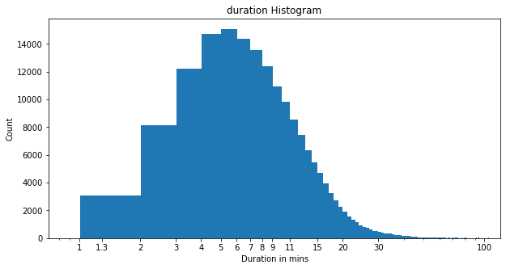

```python
plt.figure(figsize=[10,5])
plt.hist(df['duration_min'],bins=np.arange(df['duration_min'].min(),df['duration_min'].max()+1,1));
plt.xscale('log')
plt.xlim(0,120)
ticks=[1,1.3,2,3,4,5,6,7,8,9,11,15,20,30,100]
labels=[f"{x}" for x in ticks]
plt.xticks(ticks,labels);

plotd("duration Histogram","Duration in mins","Count")
```

## Trip day

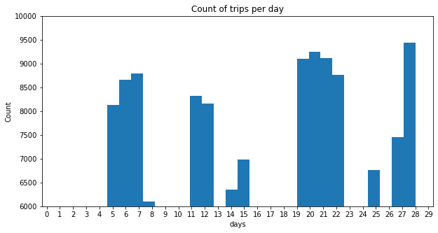

```python
#day of trip
plt.figure(figsize=[10,5])
plt.hist(df['start_day'],bins=30);
plt.ylim(6000,10000)
ticks=[x for x in range(0,30)]
labels=[f"{x}" for x in ticks]
plt.xticks(ticks,labels);
plotd("Count of trips per day","days","Count")
```

## Starting Hour

> The most start hour is 8 AM and 4 PM

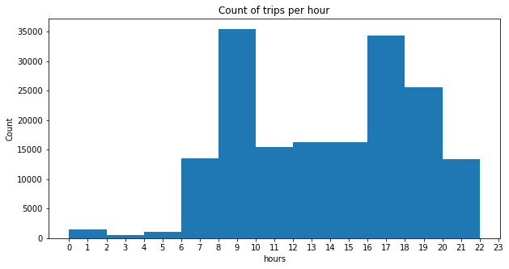

```python
#start_hour
plt.figure(figsize=[10,5])
plt.hist(df['start_hour'],bins=np.arange(df['start_hour'].min(),df['start_hour'].max()+1,2));
ticks=[x for x in range(0,24)]
labels=[f"{x}" for x in ticks]
plt.xticks(ticks,labels);

plotd("Count of trips per hour","hours","Count")
```

## The most start stations

> those are the most start stations to go on trip "Market St at 10th St" has the highest trip count followed by "San Francisco Caltrain Station 2 (Townsend St at 4th St)"

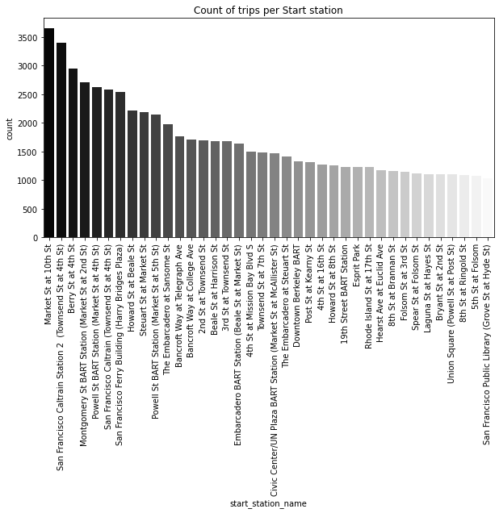

```python
filtered_data= df[df["count_of_start_station"]>1000].sort_values("count_of_start_station",ascending = False)
plt.figure(figsize=[10,5])
sb.countplot(filtered_data['start_station_name'],palette="gray");
plt.xticks(rotation = 90);
plt.title("Count of trips per Start station");
```

## Total numbers of customers vs subscriber

> Subscribers are much more than Customers

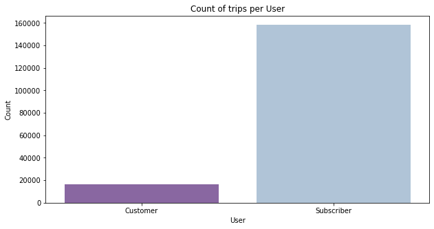

```python
#user type
plt.figure(figsize=[10,5])
sb.countplot(df['user_type'],palette='BuPu_r');

plotd("Count of trips per User","User","Count")
```

## Age of people making trips

> it seems that people aged from 30 to 35 has higher count of trip and the spike goes down with increasing in age

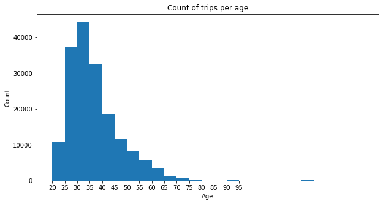

```python
plt.figure(figsize=[10,5])
plt.hist(df['age'],bins=np.arange(df['age'].min(),df['age'].max()+5,5));
ticks=[x for x in range(20,100,5)]
labels=[f"{x}" for x in ticks]
plt.xticks(ticks,labels);

plotd("Count of trips per age","Age","Count")
```

## People gender making trips

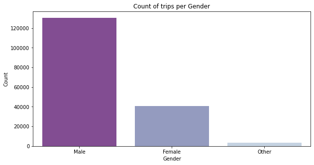

```python
#member gender
plt.figure(figsize=[10,5])

sb.countplot(df['member_gender'],palette='BuPu_r');
plotd("Count of trips per Gender","Gender","Count")
```

# Young people make longer trip duration than old people

> it seems that duration increases with age unitl 35 then the spike goes down with increasing age

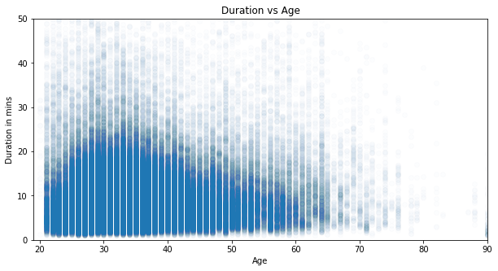

```python
plt.figure(figsize=[10,5])
plt.scatter(data=df,x='age',y='duration_min',alpha=0.01);
plt.xlim(19,90)
plt.ylim(0,50)
#considering only age under 80 and duration under 50 min

plotd("Duration vs Age","Age","Duration in mins")
```

## Average trip duration for each Start hour

> people tends to have an average longer trips during hours from 12 to 15

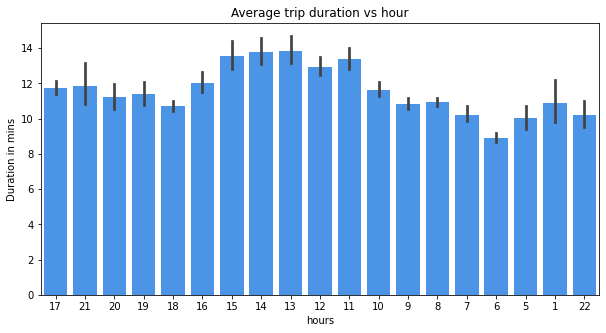

```python
plt.figure(figsize=[10,5])
sb.barplot(y='duration_min',x='start_hour',data=filtered_df,color="#3392FF",);

plotd("Average trip duration vs hour","hours","Duration in mins")
```

## Average trip duration for each day

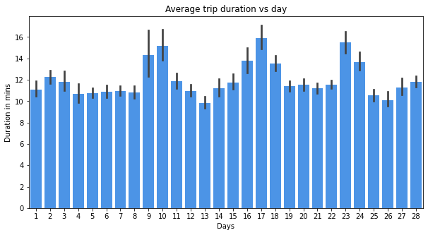

```python
plt.figure(figsize=[10,5])
sb.barplot(y='duration_min',x='start_day',data=df,color="#3392FF",);

plotd("Average trip duration vs day","Days","Duration in mins")
```

## Average Duration for each user compared to number of users

> we can't conclude that duration is higher for customer due the huge difference in number of subscribers and customers so we will create another feature to make a fair comparison

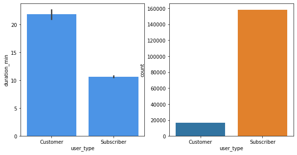

```python
#duration with user type
plt.figure(figsize=[10,5])
plt.subplot(1,2,1)
sb.barplot(y='duration_min',x='user_type',data=df,color="#3392FF",);
plt.subplot(1,2,2)
sb.countplot(df['user_type']);
```

## Average duration per user compared by user type

customers have higher average duration per user

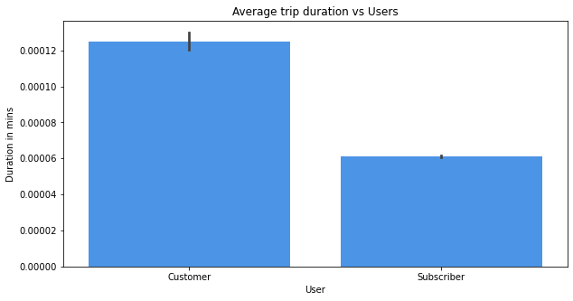

```python
plt.figure(figsize=[10,5])
sb.barplot(y='duration_per_user',x='user_type',data=filtered_df,color="#3392FF",);
plotd("Average trip duration vs Users","User","Duration in mins")
```

## Relation between duration and age with user type

> User type doesn't affect the relation between duration and age

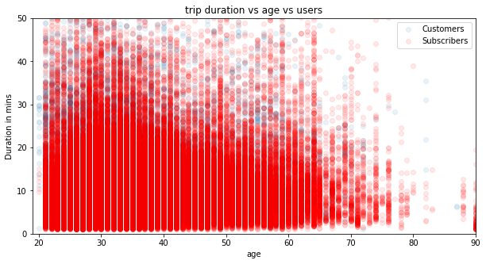

```python
plt.figure(figsize=[10,5])
plt.scatter(data=df[df['user_type']=='Customer'],x='age',y='duration_min',alpha=0.09);
plt.scatter(data=df[df['user_type']=='Subscriber'],x='age',y='duration_min',color='red',alpha=0.09);
plt.xlim(19,90)
plt.ylim(0,50)
#considering only age under 80 and duration under 50 min
plotd("trip duration vs age vs users","age","Duration in mins")
plt.legend(['Customers','Subscribers']);
```

## Relation between duration and age with member gender

> gender doesn't affect the relation between duration and age

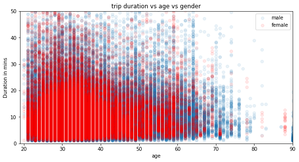

```python
plt.figure(figsize=[10,5])
plt.scatter(data=df[df['member_gender']=='Male'],x='age',y='duration_min',alpha=0.09);
plt.scatter(data=df[df['member_gender']=='Female'],x='age',y='duration_min',color='red',alpha=0.09);
#considering only age under 80 and duration under 50 min
plt.xlim(19,90)
plt.ylim(0,50)

plt.legend(['male','female']);
plotd("trip duration vs age vs gender","age","Duration in mins")
```